# Prosper Loan Data Analysis

## by Sangwon Lee

## Investigation Overview

From an investor's point of view, we want to investigate which variables affect investment returns.

## Dataset Overview

ProsperLoan contains 113,937 loans with 81 variables on each loan, including loan amount, borrower rate (or interest rate), current loan status, borrower income, and many others.

## Correlation of Estimated Return Measurements

- `EstimatedReturn` is the ratio of the total amount of estimated return that investors can receive to the actual loan amount.
- In order to invest effectively, low interest rates should be given to low-risk people so that they can get more loans, and conversely, high-risk people should be charged high interest rates so that they can make up for their loans even if they can't repay them.
- Therefore, the next heatmap can be interpreted as follows:
  - `Median Estimated Return` tends to decrease as `ProsperRating` and `IncomeRange` are higher, because it is a percentage of the total amount.
  - 'Mean of Total Amount of Estimated Return' tends to increase as 'ProsperRating' and 'IncomeRange' are higher, but it is highest in the section where 'ProsperRating' is 'B' or 'C'. This can be expected because the number of people with high credit ratings is small.

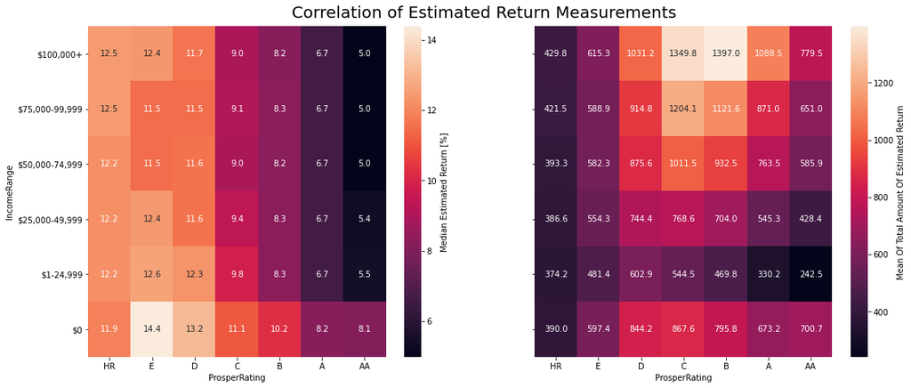

## Correlation of Actual Return Measurements

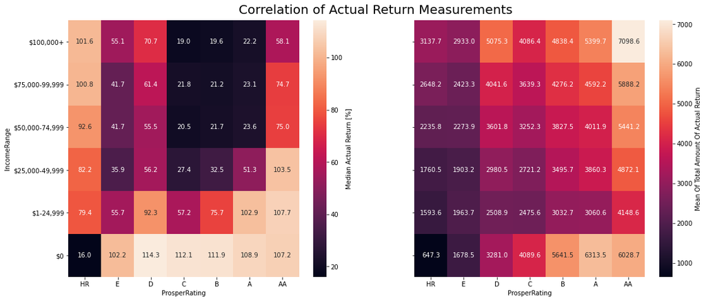

## Correlation of Estimated and Actual Return by Loan Status and Prosper Rating

- The distribution of actual return is clearly distinguished according to the loan status. In the Completed state, the actual return is greater than 1.0 because more than the principal of the loan is mostly recovered. In the current state, the actual return is greater than 0 because it is being repaid. In the case of Defaulted, since it is a case of giving up on repaying the loan, the loss cannot be larger than the actual loan amount, so it is distributed at -1.0 or higher.
- In the case of an estimated return, the loss is not considered and its value is always greater than 0. Also, unlike actual return, it is not a value for the amount actually recovered, so there is no significant change in loan status. However, it can be seen that the prosper rating is clearly divided. As you go from HR to AA, you can see that the distribution of the estimated return gets closer to 0, which, as mentioned in Correlation of Estimated Return Measurements, gives a low interest rate to people with low risk and increases the loan amount. Since what can be received can be in the investor's interest, the estimated return for the recovery ratio is lower.

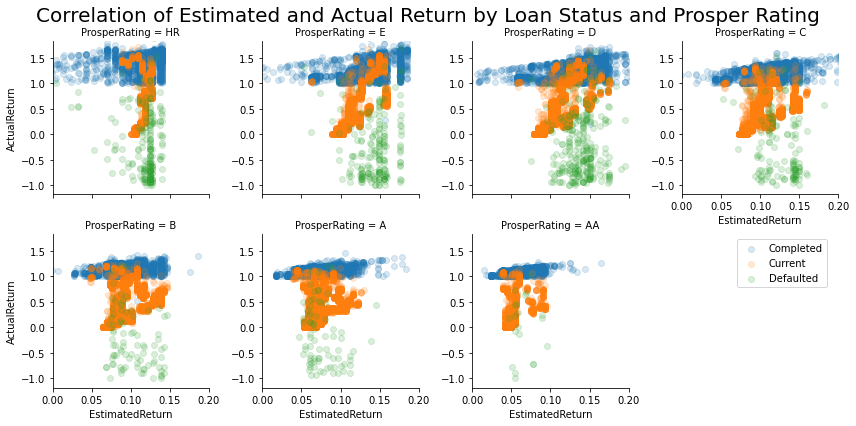